# BsMutants

zagor

2025-10-29

```r
rm(list = ls(all = TRUE))
gc()
```

```
##           used (Mb) gc trigger (Mb) max used (Mb)
## Ncells  617699 33.0    1420382 75.9   686457 36.7
## Vcells 1162505  8.9    8388608 64.0  1877160 14.4
```

# 1 packages

```r
# %>%
library(magrittr)
library(ggplot2)


`%!in%` = Negate(`%in%`)
```

# 2 palette

```r
pal = rev(RColorBrewer::brewer.pal(8, 'Paired')[c(3,1,5,7)])
```

```r
my_dir = file.path("..", "reports", "BsMutants")
if (!dir.exists(my_dir)) {
  dir.create(my_dir)
}
fr = file.path('..', 'output',  'BsMutants_stat.txt')
file.create(fr)
```

```
## [1] TRUE
```

# 3 f-ctions

## 3.1 summary stat

```r
summary_stats <- function(df, measurevar, groupvars, conf.level = 0.95) {
  df %>%
    dplyr::group_by(across(all_of(groupvars))) %>%
    dplyr::summarise(
      N = sum(!is.na(.data[[measurevar]])),
      mean = mean(.data[[measurevar]], na.rm = TRUE),
      sd = sd(.data[[measurevar]], na.rm = TRUE),
      .groups = "drop"
    ) %>%
    dplyr::mutate(
      se = sd / sqrt(N),
      ci = se * qt(conf.level/2 + 0.5, N - 1)
    )
}
```

## 3.2 scale to the average of the reference group

```r
process_data <- function(df, groupvars, measurevar, scale_treatment = "noninoculated") {

  df.long = df %>%
    tidyr::pivot_longer(cols = 3:ncol(df), names_to = "transcript",
                        values_to = measurevar, values_drop_na = TRUE)
  data.SE = summary_stats(df.long, measurevar, groupvars)
  scale_reference = data.SE %>%
    dplyr::filter(Treatment == scale_treatment) %>%
    dplyr::select(Tissue, transcript, mean) %>%
    dplyr::rename(scale_mean = mean)
  df.scaled <- dplyr::left_join(df.long, scale_reference, by = c("Tissue", "transcript")) %>%
    dplyr::mutate(scaled = .data[[measurevar]] / scale_mean) %>%
    dplyr::select(-scale_mean)
  df.scaled = df.scaled %>%
    dplyr::arrange(dplyr::desc(transcript), dplyr::desc(Treatment))
  shoots = df.scaled %>% dplyr::filter(Tissue == "shoots")
  roots = df.scaled %>% dplyr::filter(Tissue == "roots")

  return(list(
    shoots = shoots,
    roots = roots
  ))
}
```

## 3.3 permutation ANOVA & Games Howell Post-hoc Tests

- compare all possible combinations of group differences when the assumption of homogeneity of variances is violated
- provides confidence intervals for the differences between group means and shows whether the differences are statistically significant
- based on Welch’s degrees of freedom correction and uses Tukey’s studentized range distribution for computing the p-values
- compares the difference between each pair of means with appropriate adjustment for the multiple testing, so there is no need to apply additional p-value corrections
- assumes approximate normality of *residuals*

```r
games_howell_by_transcript <- function(mydata.long, measurevar = "measurement", groupvar = "Treatment") {

  temp = data.frame()

  set.seed(123456)
  # Transcripts with significant treatment effects BH < 0.05
  pA = mydata.long %>%
    dplyr::group_by(transcript) %>%
    dplyr::group_modify(~ {
      test = coin::oneway_test(measurement ~ Treatment, data = .x,
                               distribution = coin::approximate(nresample = 70)) # the smallest nonzero p one can observe is 1 / nresample
      tibble::tibble(
        statistic = as.numeric(coin::statistic(test)),
        p.value = as.numeric(coin::pvalue(test))
      )
    }) %>%
    dplyr::ungroup() %>%
    dplyr::mutate(permANOVA_BH = stats::p.adjust(p.value, method = "BH")) # If none of the resamples is as extreme, the raw estimate is 0


  cat(crayon::red("####  ####  \npermutational ANOVA\n####  ####  \n"))
  print(pA)

  cat("\nPermutational ANOVA", file = fr, append = TRUE, sep = "\n")
  header = paste(colnames(as.data.frame(pA)), collapse = "\t")
  cat(header, file = fr, append = TRUE, sep = "\n")
  output_text = apply(as.data.frame(pA), 1, function(row) paste(row, collapse = "\t"))
  cat(output_text, file = fr, append = TRUE, sep = "\n")


  temp = mydata.long %>%
  dplyr::group_by(transcript) %>%
  rstatix::games_howell_test(measurement ~ Treatment, detailed = TRUE)



  return(temp)

}
```

## 3.4 plot

```r
plot_gene_expression <- function(  data.SE
                                 , data.long
                                 , stat.test.sig
                                 , transcripts_excl = c('St13-LOX', 'StPti5')
                                 , color_values
                                 , facet_cols = 6
                                 , y_scales = NULL
                                 , dodge_width = 0.8,
                                 plot_title = ""
                                 ) {

  dodge = position_dodge(width = dodge_width)

  data.SE.filtered = dplyr::filter(data.SE, !transcript %in% transcripts_excl)
  data.long.filtered = dplyr::filter(data.long, !transcript %in% transcripts_excl)

  stat.test.filtered = NULL
  if (nrow(stat.test.sig) > 0) stat.test.filtered = dplyr::filter(stat.test.sig, !transcript %in% transcripts_excl)

  p = ggplot(data.SE.filtered, aes(x = Treatment, y = mean)) +
    geom_point(size=3.5, shape = 22, position = dodge, aes(fill = Treatment), colour = "black") +
    geom_point(data = data.long.filtered, aes(x = Treatment, y = scaled, fill = Treatment), colour = "black",
               size = 2.0, shape = 21,
               position = dodge) +
    geom_errorbar(aes(ymin = mean - se, ymax = mean + se), width = 0.3, lwd = 0.5,
                  position = dodge) +
    facet_wrap(~ transcript, ncol = facet_cols, scales = "free", drop = TRUE)

  if (!is.null(y_scales)) {
    p = p + ggh4x::facetted_pos_scales(y = y_scales)
  }

  p = p +
    # geom_hline(yintercept = 2.5, alpha = 0.0) +
    geom_hline(yintercept = 0, alpha = 0.0) +
    geom_hline(yintercept = 1, alpha = 0.5, linetype = "dotted", col = "gray45") +
    ggtitle(plot_title) +
    theme_bw() +
    scale_colour_manual(name = "", values = rev(color_values)) +
    scale_fill_manual(name = "", values = rev(color_values)) +
    labs(x = "", y = "Relative gene expression (+/- SE)"
         # , subtitle = "Permutation t-test measurements"
         ) +
    theme(plot.subtitle = element_text(size = 10),
          axis.text = element_text(size = 12.5),
          axis.text.x = element_text(size = 12.5, angle = 90),
          axis.title = element_text(size = 12.5, face = "bold"),
          strip.text = element_text(size = 12.5),
          title = element_text(size = 15, face = "bold"),
          # axis.ticks.x = element_blank(),
          legend.key.height = unit(1.5, "cm"),
          legend.key.width = unit(1.75, "cm"),
          legend.text = element_text(size = 12.5),
          legend.title = element_text(size = 12.5),
          legend.background = element_rect(fill = "transparent", size = 0.5, linetype = "dotted"),
          legend.position = "top",
          legend.justification = "right",
          plot.background = element_blank(),
          panel.grid.major = element_blank(),
          panel.grid.minor = element_blank(),
          axis.title.y.right = element_blank(),
          axis.text.y.right = element_blank(),
          # axis.ticks.y = element_blank(),
          axis.text.y = element_text(size = 12.5, margin = margin(r = 0)),
          panel.spacing = unit(1, "lines"),
          strip.background = element_rect(size = 0.5, fill = "transparent", color = NA) ,
          panel.border = element_blank(),
          axis.line = element_line(color = "black")
          )

    p = p + theme(legend.position = "none")





  if (!is.null(stat.test.filtered) && nrow(stat.test.filtered) > 0) {

    p = p + ggpubr::stat_pvalue_manual(
      stat.test.filtered,
      label = "p.adj.signif",
      xmin = "xmin",
      xmax = "xmax",
      y.position = "y.position",
      hide.ns = FALSE,
      tip.length = 0.01,
      step.increase = 0,
      inherit.aes = FALSE
    )

  }

  return(p)

}
```

## 3.5 distribution, variance and effects

- on qPCR data
  - [quantGenius - quantification of qPCR data using standard curve](http://quantgenius.nib.si/user/login)
  - [MIQE 2.0: Revision of the Minimum Information for Publication of Quantitative Real-Time PCR Experiments Guidelines](https://academic.oup.com/clinchem/article/71/6/634/8119148)
  - quantification based on a standard curve inherently involves a log transformation of the input data
- **Denote:** LOQ values skew distributions
- **Denote:** distribution tests: low power for small sample size, see QQ of residuals
  - if most or all points fall inside the shaded confidence band, the sample’s distribution does not show strong evidence of departure from normality at the plotted sample size and confidence level
  - a few isolated points outside the band at the extremes are common with small samples and do not necessarily indicate a severe problem
- **Denote:** heteroscedasticity: some tests are meant to be used with normally distributed data, but can tolerate relatively low deviation from normality; Levene’s test with mean, more robust test Brown-Forsythe with median, Fligner-Killeen when data are non-normally distributed or when problems related to outliers in the dataset cannot be resolved
- **Denote:** effect size: Cohen’s d - parametric with assumptions, Wilcoxon Effect Size - the non-parametric alternative; different sensitivity to outliers

```r
dens_and_effect <- function(mydata.long, p_colors) {

  # Plot density with x="measurement"
  p1 = ggpubr::ggdensity(mydata.long, x = "measurement",
              add = "mean", rug = TRUE,
              color = "Treatment", fill = "Treatment",
              facet.by = 'transcript') +
    scale_fill_manual(name = "", values = rev(p_colors)) +
    scale_color_manual(name = "", values = rev(p_colors)) +
    ggtitle("measurement") +
    facet_wrap(~transcript, ncol = 4, scales = "free")
  print(p1)

  # optional: Plot density with x="scaled"- sam e shape wih a shift
  # p2 = ggpubr::ggdensity(mydata.long, x = "scaled",
  #             add = "mean", rug = TRUE,
  #             color = "Treatment", fill = "Treatment",
  #             facet.by = 'transcript') +
  #   scale_fill_manual(name = "", values = rev(p_colors)) +
  #   scale_color_manual(name = "", values = rev(p_colors)) +
  #   ggtitle("scaled") +
  #   facet_wrap(~transcript, ncol = 4, scales = "free")
  # print(p2)


  cat(crayon::red('####  ####  \nDistribution tests\n####  ####  \n'))

    distr_tests = mydata.long %>%
    dplyr::group_by(transcript) %>%
    dplyr::group_map(~ {
      x = na.omit(.x$measurement)
      if (length(x) < 3) {
        return(tibble::tibble(
          Shapiro_Wilk = NA_real_,
          Anderson_Darling = NA_real_,
          Lilliefors_KS = NA_real_,
          Jarque_Bera = NA_real_,
          DAgostino_Skewness = NA_real_,
          n = length(x),
          transcript = .y$transcript
        ))
      }
      tibble::tibble(
        Shapiro_Wilk = tryCatch(shapiro.test(x)$p.value, error = function(e) NA_real_),
        Anderson_Darling = tryCatch(nortest::ad.test(x)$p.value, error = function(e) NA_real_),
        Lilliefors_KS = tryCatch(nortest::lillie.test(x)$p.value, error = function(e) NA_real_),
        Jarque_Bera = tryCatch(tseries::jarque.bera.test(x)$p.value, error = function(e) NA_real_),
        DAgostino_Skewness = tryCatch(moments::agostino.test(x)$p.value, error = function(e) NA_real_),
        n = length(x),
        transcript = .y$transcript
      )
    }) %>%
    dplyr::bind_rows() %>%
    dplyr::ungroup() %>%
    dplyr::mutate(
      Shapiro_Wilk_BH = stats::p.adjust(Shapiro_Wilk, method = "BH"),
      Anderson_Darling_BH = stats::p.adjust(Anderson_Darling, method = "BH"),
      Lilliefors_KS_BH = stats::p.adjust(Lilliefors_KS, method = "BH"),
      Jarque_Bera_BH = stats::p.adjust(Jarque_Bera, method = "BH"),
      DAgostino_Skewness_BH = stats::p.adjust(DAgostino_Skewness, method = "BH")
    )



  combined_results = distr_tests[grep("^n$|transcript|_BH", colnames(distr_tests))]
  print(combined_results, n = Inf, width = Inf)




  cat(crayon::red("####  ####  \nQuantile-Quantile plots\n####  ####  \n"))
  qq_plot_list = mydata.long %>%
    dplyr::group_by(transcript) %>%
    dplyr::group_map(~ {
      ggpubr::ggqqplot(.x$measurement) +
        ggplot2::ggtitle(paste("Raw:", .y$transcript))
    })

  resid_qq_list = mydata.long %>%
    dplyr::group_by(transcript) %>%
    dplyr::group_map(~ {
      model = lm(measurement ~ Treatment, data = .x)
      resids = resid(model)
      ggpubr::ggqqplot(resids) +
        ggplot2::ggtitle(paste("Residuals:", .y$transcript))
    })


  resid_density_list = mydata.long %>%
    dplyr::group_by(transcript) %>%
    dplyr::group_map(~ {
      model = lm(measurement ~ Treatment, data = .x)
      resids = scale(resid(model))  # standardize residuals
      df = data.frame(resids = as.numeric(resids))
      ggplot(df, aes(x = resids)) +
        geom_density(fill = "steelblue", alpha = 0.6) +
        stat_function(fun = dnorm, color = "red", linetype = "dashed") +
        ggtitle(paste("Residuals:", .y$transcript)) +
        theme_minimal()
    })

  # Arrange and print all plots
  qq_arranged = ggpubr::ggarrange(plotlist = qq_plot_list, ncol = 4, nrow = ceiling(length(qq_plot_list) / 4))
  resid_qq_arranged = ggpubr::ggarrange(plotlist = resid_qq_list, ncol = 4, nrow = ceiling(length(resid_qq_list) / 4))
  resid_hist_arranged = ggpubr::ggarrange(plotlist = resid_density_list, ncol = 4, nrow = ceiling(length(resid_density_list) / 4))

  print(qq_arranged)
  print(resid_qq_arranged)
  print(resid_hist_arranged)

  # Return invisibly
  invisible(list(qq = qq_arranged, resid_qq = resid_qq_arranged, resid_hist = resid_hist_arranged))




  cat(crayon::red("####  ####  \nTest for homogeneity of variance across groups\n####  ####  \n"))

  cat(crayon::red("####  ####  \nLevene\n####  ####  \n"))
  # Levene's test on measurement
  lev_meas = mydata.long %>%
    dplyr::group_by(transcript) %>%
    rstatix::levene_test(measurement ~ Treatment, center = "mean")
  print(lev_meas)

  cat(crayon::red("####  ####  \nBrown-Forsythe\n####  ####  \n"))
  # center = "median" switches Levene’s test to the Brown-Forsythe variant
  bf_meas = mydata.long %>%
    dplyr::group_by(transcript) %>%
    rstatix::levene_test(measurement ~ Treatment, center = "median")
  print(bf_meas)

  cat(crayon::red("####  ####  \nFligner\n####  ####  \n"))
  fk_meas = mydata.long %>%
    dplyr::group_by(transcript) %>%
    dplyr::group_modify(~ broom::tidy(stats::fligner.test(measurement ~ Treatment, data = .x)))
  print(fk_meas)




  cat(crayon::red("####  ####  \nWilcoxon effect size\n####  ####  \n"))

  # Wilcoxon effect size on measurement
  eff_meas = mydata.long %>%
    dplyr::group_by(transcript) %>%
    rstatix::wilcox_effsize(measurement ~ Treatment)
  print(eff_meas)

  # Wilcoxon effect size on scaled
  # eff_scaled = mydata.long %>%
  #   dplyr::group_by(transcript) %>%
  #   rstatix::wilcox_effsize(scaled ~ Treatment)
  # print(eff_scaled)

  cat(crayon::red("####  ####  \nCohen's d Measure of Effect Size\n####  ####  \n"))

  # Cohen's d on measurement
  coh_meas = mydata.long %>%
    dplyr::group_by(transcript) %>%
    rstatix::cohens_d(measurement ~ Treatment, paired = FALSE)
  print(coh_meas)


  invisible(list(
    p_measurement = p1,
    distr_measurement = combined_results,
    levene_measurement = lev_meas,
    brownforsythe_measurement = bf_meas,
    fligner_measurement = fk_meas,
    wilcoxon_measurement = eff_meas,
    cohensd_measurement = coh_meas
  ))
}
```

## 3.6 ggplot limits

```r
make_scale_params <- function(maxval) {
  upper = ifelse(maxval > 2, maxval + 2, maxval + 0.1) # 0.5
  step = dplyr::case_when(
    maxval >= 50 ~ 25,
    maxval >= 30 ~ 10,
    maxval >= 15 ~ 5,
    maxval >= 10 ~ 2,
    maxval >  2  ~ 1,
    TRUE         ~ 0.5
  )
  upper_round = ceiling(upper / step) * step
  breaks = seq(0, upper_round, by = step)
  list(limits = c(0, upper_round), breaks = breaks)
}

build_y_scales_for <- function(names_vec, max_per_transcript) {
  max_per_transcript %>%
    dplyr::filter(transcript %in% names_vec) %>%
    purrr::pmap(function(transcript, max_scaled) {
      params = make_scale_params(max_scaled)
      lhs = rlang::expr(transcript == !!transcript)
      rhs = rlang::expr(ggplot2::scale_y_continuous(limits = !!params$limits, breaks = !!params$breaks))
      rlang::new_formula(lhs, rhs)
    })
}
```

## 3.7 test and plot

```r
test_and_plot <- function(data_long_raw
                          , myorder
                          , pal
                          , what
                          , plot_gene_expression_func
                          , groupvars = c("Treatment", "transcript")
                          , y_scales1
                          , y_scales2
                          ) {


  mydata.long = dplyr::as_tibble(data.table::data.table(data_long_raw))
  mydata.long$transcript = factor(mydata.long$transcript, levels = myorder)
  mydata.long = mydata.long %>% dplyr::arrange(factor(transcript, levels = myorder))

  mydata.long.SE = summary_stats(mydata.long, measurevar = "scaled", groupvars = groupvars)

  results = dens_and_effect(mydata.long, p_colors = pal)

  cat(what, file = fr, append = TRUE, sep = "\n")

  cat("\nDistribution tests", file = fr, append = TRUE, sep = "\n")
  header = paste(colnames(results$distr_measurement), collapse = "\t")
  cat(header, file = fr, append = TRUE, sep = "\n")
  output_text = apply(results$distr_measurement, 1, function(row) paste(row, collapse = "\t"))
  cat(output_text, file = fr, append = TRUE, sep = "\n")

  cat("\nLevene's test for homogeneity of variance across groups", file = fr, append = TRUE, sep = "\n")
  header = paste(colnames(results$levene_measurement), collapse = "\t")
  cat(header, file = fr, append = TRUE, sep = "\n")
  output_text = apply(results$levene_measurement, 1, function(row) paste(row, collapse = "\t"))
  cat(output_text, file = fr, append = TRUE, sep = "\n")
  cat("\nBrown-Forsythe (Levene with median)", file = fr, append = TRUE, sep = "\n")
  header = paste(colnames(results$brownforsythe_measurement), collapse = "\t")
  cat(header, file = fr, append = TRUE, sep = "\n")
  output_text = apply(results$brownforsythe_measurement, 1, function(row) paste(row, collapse = "\t"))
  cat(output_text, file = fr, append = TRUE, sep = "\n")
  cat("\nFligner-Killeen test of homogeneity of variances", file = fr, append = TRUE, sep = "\n")
  header = paste(colnames(results$fligner_measurement), collapse = "\t")
  cat(header, file = fr, append = TRUE, sep = "\n")
  output_text = apply(results$fligner_measurement, 1, function(row) paste(row, collapse = "\t"))
  cat(output_text, file = fr, append = TRUE, sep = "\n")

  cat("\nWilcoxon effect size", file = fr, append = TRUE, sep = "\n")
  header = paste(colnames(results$wilcoxon_measurement), collapse = "\t")
  cat(header, file = fr, append = TRUE, sep = "\n")
  output_text = apply(results$wilcoxon_measurement, 1, function(row) paste(row, collapse = "\t"))
  cat(output_text, file = fr, append = TRUE, sep = "\n")
  cat("\nCohen's d Measure of Effect Size", file = fr, append = TRUE, sep = "\n")
  header = paste(colnames(results$cohensd_measurement), collapse = "\t")
  cat(header, file = fr, append = TRUE, sep = "\n")
  output_text = apply(results$cohensd_measurement, 1, function(row) paste(row, collapse = "\t"))
  cat(output_text, file = fr, append = TRUE, sep = "\n")

  cat("", file = fr, append = TRUE, sep = "\n")


  temp = games_howell_by_transcript(mydata.long, measurevar = "measurement", groupvar = "Treatment")
  stat.test = temp %>%
    dplyr::select(transcript, group1, group2, p.adj, p.adj.signif)

  # y_pos_df computed from (means+se)
  y_pos_df = mydata.long.SE %>%
    dplyr::group_by(transcript) %>%
    dplyr::summarise(
      max_mean_se = max(mean + se, na.rm = TRUE),
      min_mean_se = min(mean - se, na.rm = TRUE),
      .groups = "drop"
    ) %>%
    dplyr::left_join(
      mydata.long %>%
        dplyr::group_by(transcript) %>%
        dplyr::summarise(
          max_scaled = max(scaled, na.rm = TRUE),
          min_scaled = min(scaled, na.rm = TRUE),
          .groups = "drop"
        ),
      by = "transcript"
    ) %>%
    dplyr::mutate(
      plot_max = pmax(max_mean_se, max_scaled, na.rm = TRUE),
      plot_min = pmin(min_mean_se, min_scaled, na.rm = TRUE),
      plot_range = pmax(plot_max - plot_min, 1e-6)
    ) %>%
    dplyr::select(transcript, plot_max, plot_range)

  # map group names to numeric x positions (use existing factor levels as-is)
  pos_map = mydata.long %>%
    dplyr::distinct(transcript, Treatment) %>%
    dplyr::mutate(xpos = as.numeric(factor(Treatment, levels = levels(mydata.long$Treatment))))

  # attach plot ranges and numeric x positions to stat.test
  stat.test = stat.test %>%
    dplyr::left_join(y_pos_df, by = "transcript") %>%
    dplyr::left_join(pos_map %>% dplyr::rename(group1 = Treatment, xmin = xpos), by = c("transcript", "group1")) %>%
    dplyr::left_join(pos_map %>% dplyr::rename(group2 = Treatment, xmax = xpos), by = c("transcript", "group2")) %>%
    dplyr::mutate(
      xmin = dplyr::if_else(is.na(xmin), as.numeric(factor(group1, levels = levels(mydata.long$Treatment))), xmin),
      xmax = dplyr::if_else(is.na(xmax), as.numeric(factor(group2, levels = levels(mydata.long$Treatment))), xmax)
    )

  # compute distinct y.position per comparison
  stat.test.sig = stat.test %>%
    dplyr::filter(!is.na(p.adj) & p.adj <= 0.05) %>% # take care if < 0.05 OR <= 0.05
    dplyr::group_by(transcript) %>%
    dplyr::arrange(xmin, xmax, .by_group = TRUE) %>%
    dplyr::mutate(
      base_y = plot_max + 0.03 * plot_range,
      inc = 0.05 * plot_range,
      y.position = base_y + (dplyr::row_number() - 1) * inc
    ) %>%
    dplyr::ungroup() %>%
    dplyr::select(transcript, group1, group2, p.adj, p.adj.signif, y.position, xmin, xmax)

  group1 =  sapply(y_scales1, function(x) {
    s = deparse(x)
    s_full = paste(s, collapse = " ")
    sub('.*transcript == *"([^"]+)".*', '\\1', s_full)
  })
  group2 =  sapply(y_scales2, function(x) {
    s = deparse(x)
    s_full = paste(s, collapse = " ")
    sub('.*transcript == *"([^"]+)".*', '\\1', s_full)
  })


  p1 = plot_gene_expression_func(
    data.SE = mydata.long.SE
    ,
    data.long = mydata.long
    ,
    stat.test.sig = stat.test.sig
    ,
    transcripts_excl = group2
    ,
    facet_cols = length(group1)
    ,
    color_values = pal
    ,
    plot_title = what
    ,
    y_scales = y_scales1
    ,
    dodge_width = 0.8
  )
  print(p1)

  p2 = plot_gene_expression_func(
    data.SE = mydata.long.SE,
    data.long = mydata.long,
    stat.test.sig = stat.test.sig,
    transcripts_excl = group1,
    facet_cols = length(group2),
    color_values = pal,
    plot_title = what,
    y_scales = y_scales2,
    dodge_width = 0.8
  )
  print(p2)

  return(list(plot1 = p1, plot2 = p2, stat.test = stat.test))
}
```

# 4 input

```r
fp = file.path('..', "input")
# list.files(fp)


fn = 'Table_combinedInputs.xlsx'
wb = openxlsx::loadWorkbook(file.path(fp, fn))
sheet_names = names(wb)
sheet_name = grep("BsMutants", sheet_names, value = TRUE)


df = openxlsx::read.xlsx(xlsxFile = file.path(fp, fn),
                            sheet = sheet_name,
                            startRow = 10,
                            colNames = TRUE,
                            rowNames = FALSE,
                            detectDates = FALSE,
                            skipEmptyRows = TRUE,
                            skipEmptyCols = TRUE,
                            rows = NULL,
                            cols = NULL,
                            check.names = FALSE,
                            sep.names = ".",
                            namedRegion = NULL,
                            na.strings = "NA",
                            fillMergedCells = FALSE)

data.table::setDT(df)
df[, Sample.ID := NULL]
df[, Genotype := NULL]
df$Tissue = as.factor(trimws(df$Tissue))
df$Treatment = ifelse(is.na(df$Strain), df$Treatment, trimws(df$Strain))
df$Treatment = factor(df$Treatment, levels = c("noninoculated", "PS-216", "PS-216 ΔcomQXP", "PS-216 srfA"))
df[, Strain := NULL]

numeric_cols = sapply(df, is.numeric)
min_vals = sapply(df[, ..numeric_cols], function(x) min(x, na.rm = TRUE))
LOQs = do.call(rbind, lapply(names(min_vals), function(col) {
  smallest_val = min_vals[[col]]
  values = df[[col]]
  repeated_vals = values[values == smallest_val]
  if(length(repeated_vals) > 1) {
    data.frame(
      Column = col,
      SmallestRepeatedValue = smallest_val,
      Count = length(repeated_vals)
    )
  } else {
    NULL
  }
}))

LOQs
```

```
##    Column SmallestRepeatedValue Count
## 1 StBGLU2              0.004127     2
## 2  StCPI8              0.000040     2
## 3 StRBOHD              0.016264     2
```

# 5 params

```r
groupvars = c("Tissue", "Treatment", "transcript")
measurevar = 'measurement'
dodge = position_dodge(width = 0.5)

myorder = c("StRBOHD", "StPR1B", "StCPI8", "StCAB", "StBGLU2", "StHSP70", "StPti5", "St13-LOX")
group1_names = c("StCAB", "StRBOHD", "StPti5", "St13-LOX")
```

# 6 results

```r
shoots = process_data(df, groupvars, measurevar, scale_treatment = "noninoculated")$shoots
roots = process_data(df, groupvars, measurevar, scale_treatment = "noninoculated")$roots
```

## 6.1 shoots

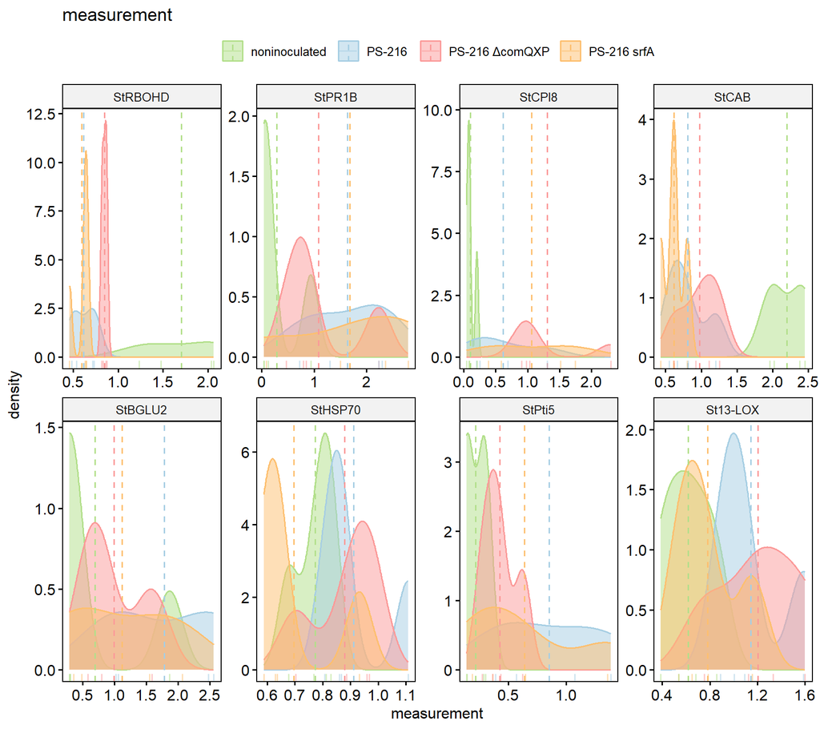

```
## ####  ####
## Distribution tests
## ####  ####
```

```
## # A tibble: 8 × 7
##       n transcript Shapiro_Wilk_BH Anderson_Darling_BH Lilliefors_KS_BH
##   <int> <fct>                <dbl>               <dbl>            <dbl>
## 1    16 StRBOHD             0.0149             0.00735          0.00280
## 2    16 StPR1B              0.125              0.189            0.358
## 3    16 StCPI8              0.135              0.219            0.546
## 4    16 StCAB               0.0261             0.0181           0.297
## 5    15 StBGLU2             0.125              0.189            0.546
## 6    16 StHSP70             0.876              0.870            0.901
## 7    16 StPti5              0.0194             0.0151           0.127
## 8    16 St13-LOX            0.629              0.756            0.901
##   Jarque_Bera_BH DAgostino_Skewness_BH
##            <dbl>                 <dbl>
## 1          0.610                0.0995
## 2          0.658                0.598
## 3          0.658                0.235
## 4          0.658                0.220
## 5          0.658                0.469
## 6          0.860                0.755
## 7          0.610                0.0995
## 8          0.742                0.469
## ####  ####
## Quantile-Quantile plots
## ####  ####
```

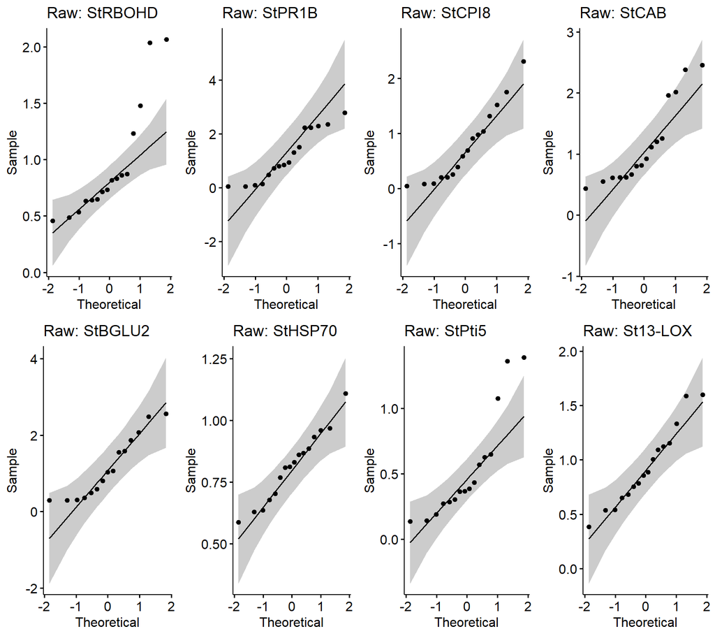

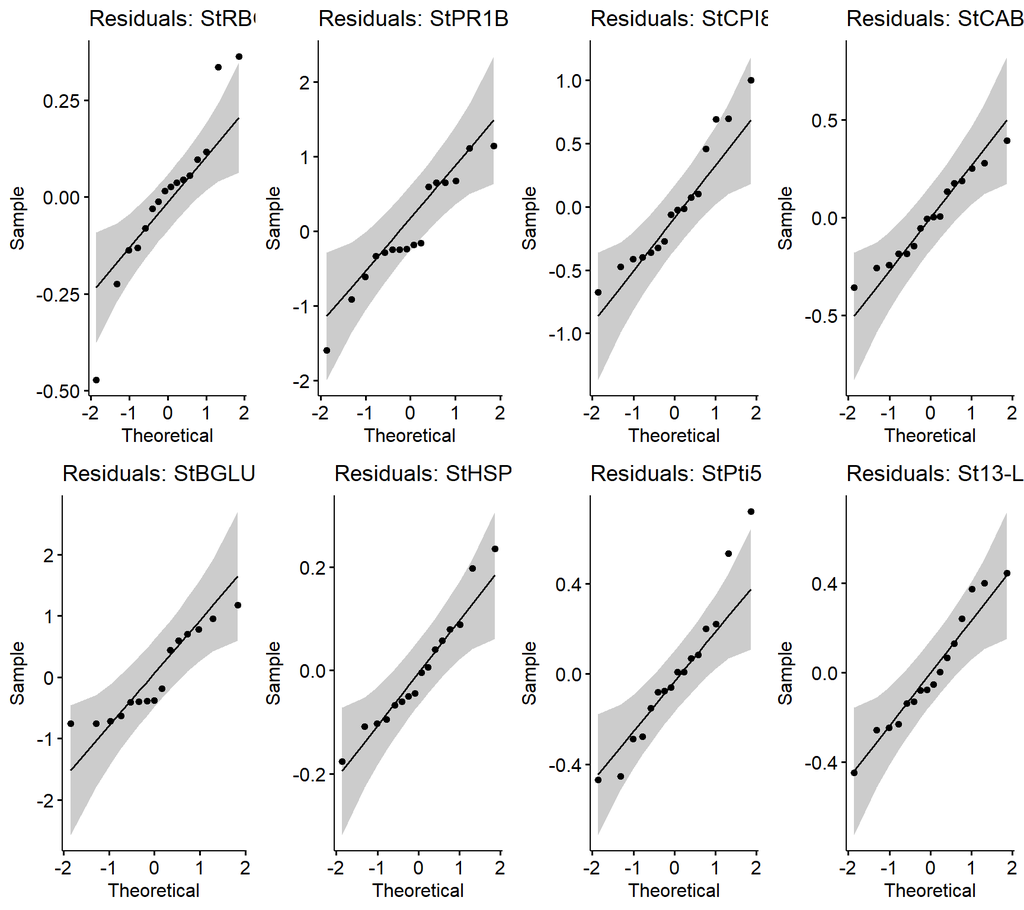

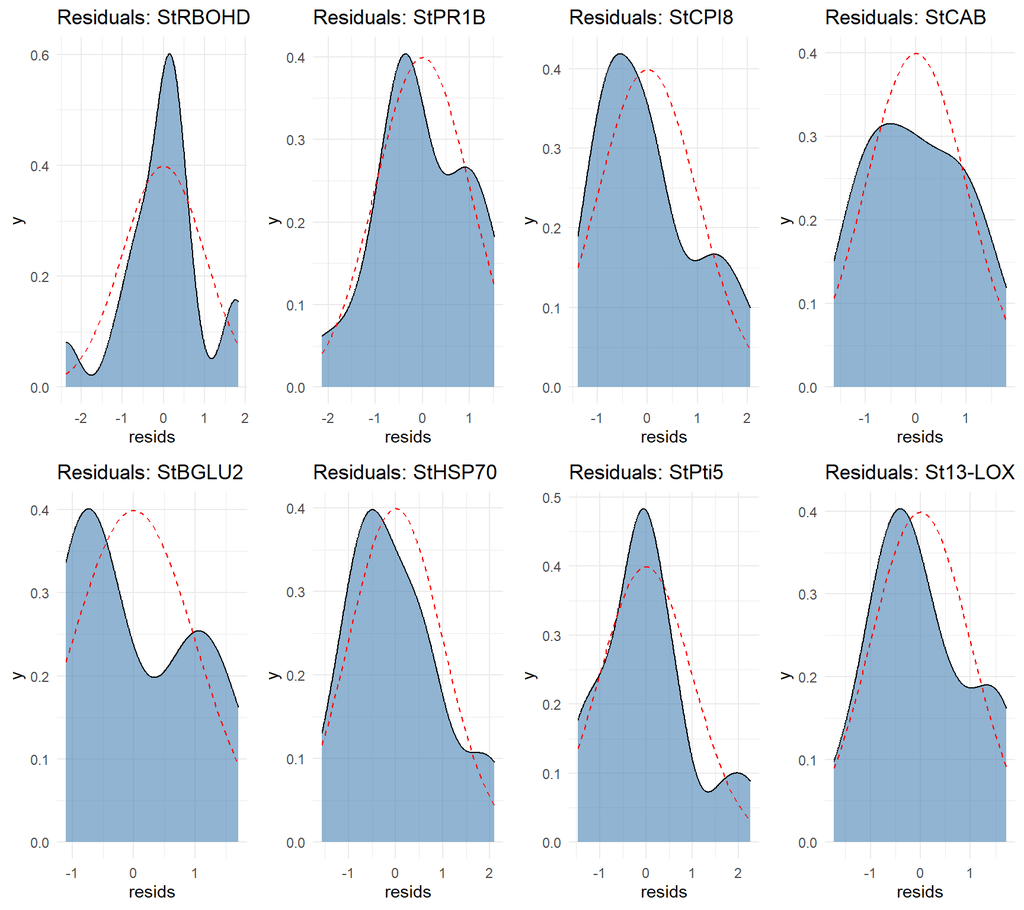

```
## ####  ####
## Test for homogeneity of variance across groups
## ####  ####
## ####  ####
## Levene
## ####  ####
## # A tibble: 8 × 5
##   transcript   df1   df2 statistic         p
##   <fct>      <int> <int>     <dbl>     <dbl>
## 1 StRBOHD        3    12    26.3   0.0000147
## 2 StPR1B         3    12     1.34  0.308
## 3 StCPI8         3    12     4.36  0.0269
## 4 StCAB          3    12     0.869 0.484
## 5 StBGLU2        3    11     1.23  0.346
## 6 StHSP70        3    12     0.746 0.545
## 7 StPti5         3    12     3.52  0.0487
## 8 St13-LOX       3    12     0.365 0.779
## ####  ####
## Brown-Forsythe
## ####  ####
## # A tibble: 8 × 5
##   transcript   df1   df2 statistic        p
##   <fct>      <int> <int>     <dbl>    <dbl>
## 1 StRBOHD        3    12    16.0   0.000172
## 2 StPR1B         3    12     1.07  0.399
## 3 StCPI8         3    12     1.56  0.251
## 4 StCAB          3    12     0.759 0.538
## 5 StBGLU2        3    11     0.721 0.560
## 6 StHSP70        3    12     0.113 0.951
## 7 StPti5         3    12     2.89  0.0793
## 8 St13-LOX       3    12     0.261 0.852
## ####  ####
## Fligner
## ####  ####
## # A tibble: 8 × 5
## # Groups:   transcript [8]
##   transcript statistic p.value parameter method
##   <fct>          <dbl>   <dbl>     <dbl> <chr>
## 1 StRBOHD       11.5   0.00914         3 Fligner-Killeen test of homogeneity of…
## 2 StPR1B         3.46  0.326           3 Fligner-Killeen test of homogeneity of…
```

[output cut: 39 more lines]

```
## # ℹ 38 more rows
## ####  ####
## permutational ANOVA
## ####  ####
## # A tibble: 8 × 4
##   transcript statistic p.value permANOVA_BH
##   <fct>          <dbl>   <dbl>        <dbl>
## 1 StRBOHD        12.7   0            0
## 2 StPR1B          5.66  0.0857       0.0980
## 3 StCPI8          7.34  0.0571       0.0980
## 4 StCAB          13.4   0            0
## 5 StBGLU2         3.84  0.271        0.271
## 6 StHSP70         5.73  0.0857       0.0980
## 7 StPti5          5.61  0.0857       0.0980
## 8 St13-LOX        7.33  0.0429       0.0980
```

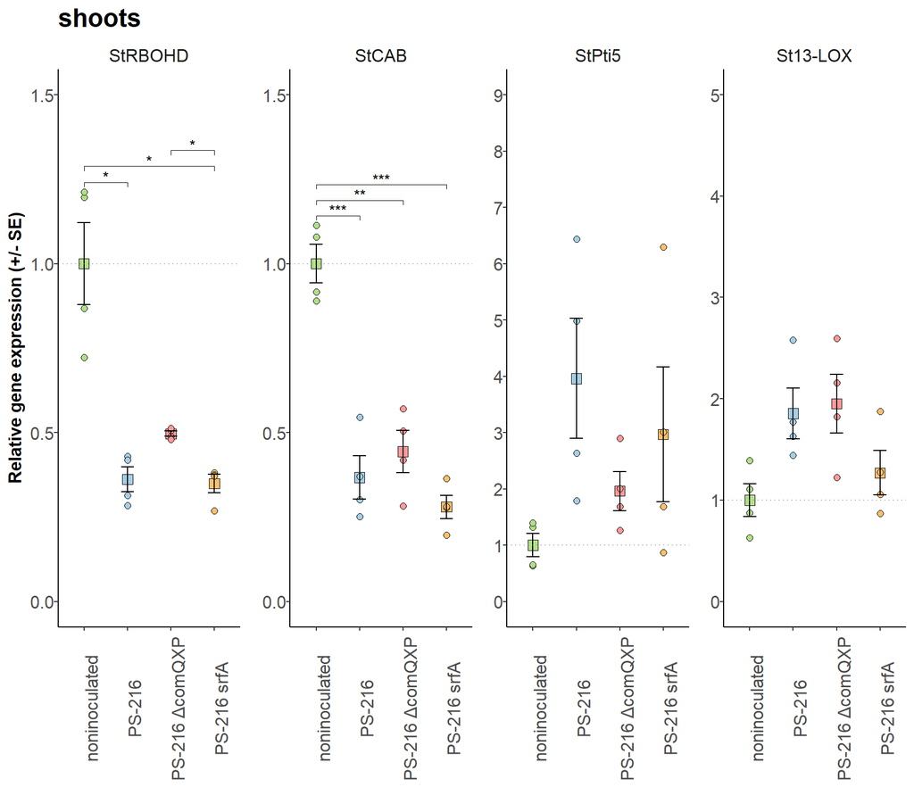

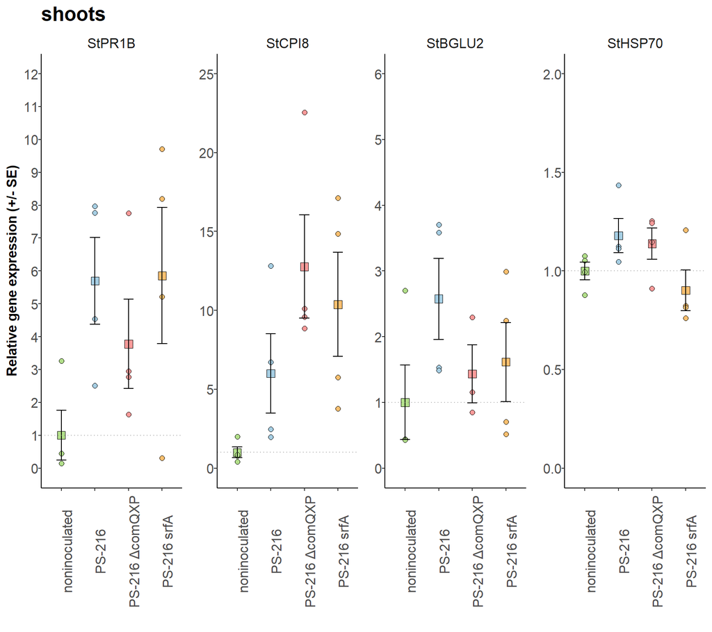

```r
max_per_transcript = shoots %>%
  dplyr::group_by(transcript) %>%
  dplyr::summarise(max_scaled = max(scaled, na.rm = TRUE), .groups = "drop")
group2_names = setdiff(max_per_transcript$transcript, group1_names)
y_scales1 = build_y_scales_for(group1_names, max_per_transcript)
y_scales2 = build_y_scales_for(group2_names, max_per_transcript)


result = test_and_plot(data_long_raw = shoots
                       , myorder = myorder
                       , pal = pal
                       , what = "shoots"
                       , plot_gene_expression_func = plot_gene_expression
                       , groupvars = c("Treatment", "transcript")
                       , y_scales1
                       , y_scales2
                       )
```

```r
res = result$stat.test[, grep("transcript|group1|group2|^p$|p\\.", colnames(result$stat.test))]
print(res[res$p.adj.signif != 'ns', ])
```

```
## # A tibble: 6 × 5
##   transcript group1         group2            p.adj p.adj.signif
##   <fct>      <chr>          <chr>             <dbl> <chr>
## 1 StRBOHD    noninoculated  PS-216         0.032    *
## 2 StRBOHD    noninoculated  PS-216 srfA    0.034    *
## 3 StRBOHD    PS-216 ΔcomQXP PS-216 srfA    0.029    *
## 4 StCAB      noninoculated  PS-216         0.001    ***
## 5 StCAB      noninoculated  PS-216 ΔcomQXP 0.002    **
## 6 StCAB      noninoculated  PS-216 srfA    0.000479 ***
```

```r
cat("", file = fr, append = TRUE, sep = "\n")
output_text = "Games Howell"
cat(output_text, file = fr, append = TRUE, sep = "\n")
header = paste(colnames(res), collapse = "\t")
cat(header, file = fr, append = TRUE, sep = "\n")
output_text = apply(as.data.frame(tibble::as_tibble(res)), 1, function(row) paste(row, collapse = "\t"))
cat(output_text, file = fr, append = TRUE, sep = "\n")
cat("", file = fr, append = TRUE, sep = "\n")
cat("", file = fr, append = TRUE, sep = "\n")




ggsave(
  filename = file.path(my_dir, "shoots_1.pdf"),
  plot = result$plot1,
  device = pdf,
  path = NULL,
  scale = 1,
  width = 6,
  height = 8,
  units = c("in"),
  dpi = 900,
  limitsize = TRUE,
  bg = NULL
)
ggsave(
  filename = file.path(my_dir, "shoots_1.svg"),
  plot = result$plot1,
  device = svg,
  path = NULL,
  scale = 1,
  width = 6,
  height = 8,
  units = "in",
  dpi = 900,
  limitsize = TRUE,
  bg = NULL
)

ggsave(
  filename = file.path(my_dir, "shoots_2.pdf"),
  plot = result$plot2,
  device = pdf,
  path = NULL,
  scale = 1,
  width = 6,
  height = 8,
  units = c("in"),
  dpi = 900,
  limitsize = TRUE,
  bg = NULL
)
ggsave(
  filename = file.path(my_dir, "shoots_2.svg"),
  plot = result$plot2,
  device = svg,
  path = NULL,
  scale = 1,
  width = 6,
  height = 8,
  units = "in",
  dpi = 900,
  limitsize = TRUE,
  bg = NULL
)
```

## 6.2 roots

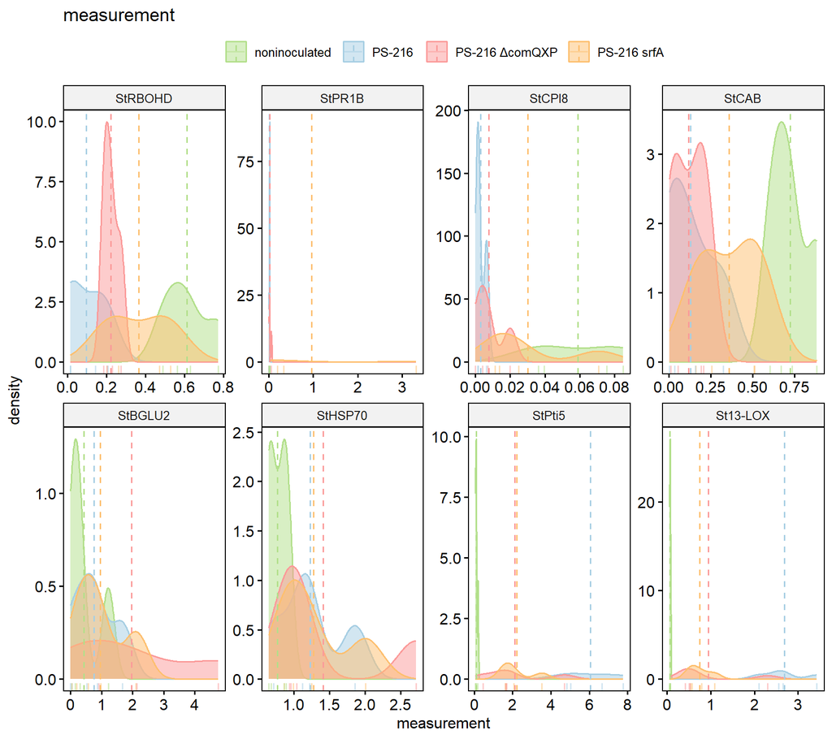

```
## ####  ####
## Distribution tests
## ####  ####
## # A tibble: 8 × 7
##       n transcript Shapiro_Wilk_BH Anderson_Darling_BH Lilliefors_KS_BH
##   <int> <fct>                <dbl>               <dbl>            <dbl>
## 1    16 StRBOHD        0.224                  1.44e- 1      0.0801
## 2    16 StPR1B         0.000000990            1.63e-11      0.000000683
## 3    15 StCPI8         0.0139                 9.86e- 3      0.117
## 4    16 StCAB          0.151                  1.47e- 1      0.240
## 5    16 StBGLU2        0.00500                9.63e- 3      0.0889
## 6    16 StHSP70        0.00500                4.58e- 3      0.0221
## 7    16 StPti5         0.0529                 5.84e- 2      0.0801
## 8    16 St13-LOX       0.0139                 9.63e- 3      0.0253
##   Jarque_Bera_BH DAgostino_Skewness_BH
##            <dbl>                 <dbl>
## 1       0.603               0.346
## 2       0                   0.00000910
## 3       0.539               0.118
## 4       0.565               0.329
## 5       0.000613            0.00465
## 6       0.0297              0.0108
## 7       0.565               0.211
## 8       0.539               0.172
## ####  ####
## Quantile-Quantile plots
## ####  ####
```

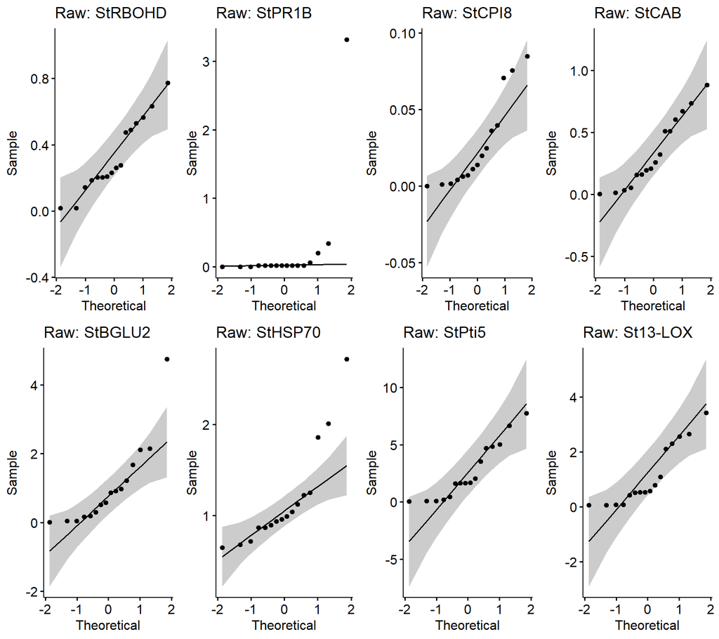

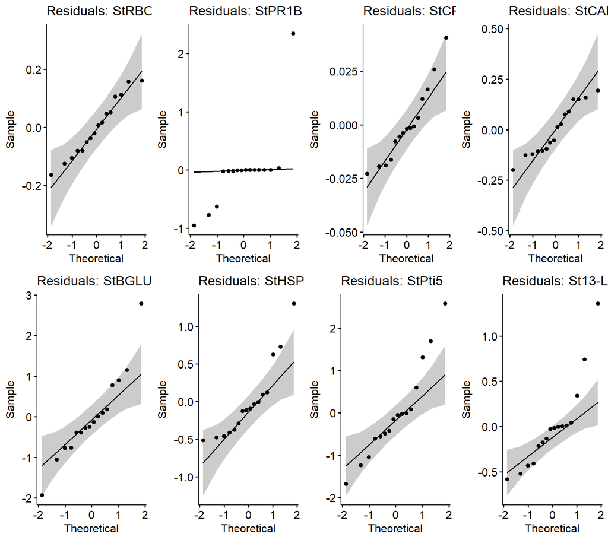

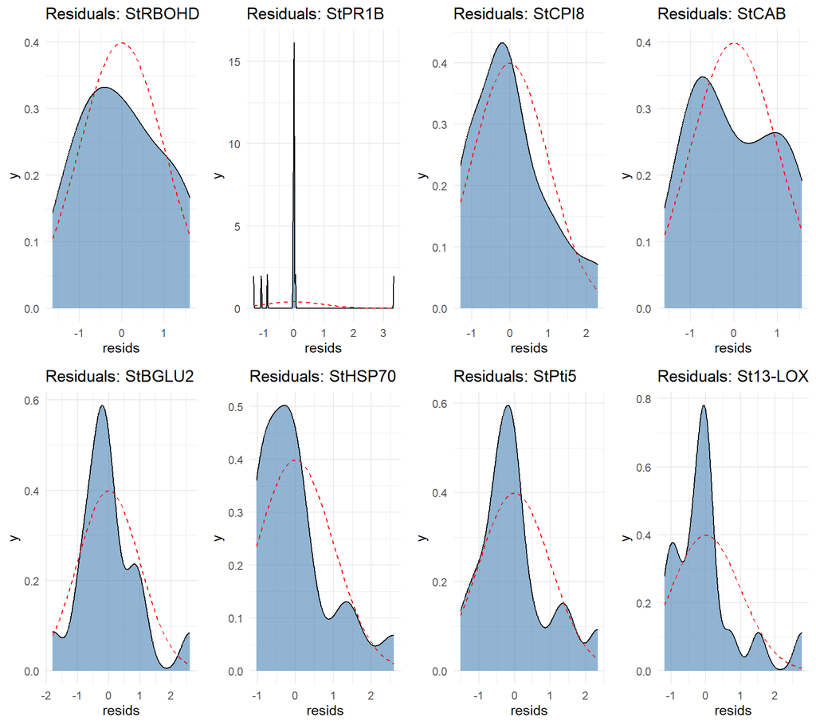

```
## ####  ####
## Test for homogeneity of variance across groups
## ####  ####
## ####  ####
## Levene
## ####  ####
## # A tibble: 8 × 5
##   transcript   df1   df2 statistic       p
##   <fct>      <int> <int>     <dbl>   <dbl>
## 1 StRBOHD        3    12      4.62 0.0227
## 2 StPR1B         3    12      8.60 0.00257
## 3 StCPI8         3    11      4.81 0.0224
## 4 StCAB          3    12      1.40 0.291
## 5 StBGLU2        3    12      2.33 0.126
## 6 StHSP70        3    12      2.19 0.142
## 7 StPti5         3    12      3.38 0.0543
## 8 St13-LOX       3    12      3.81 0.0396
## ####  ####
## Brown-Forsythe
## ####  ####
## # A tibble: 8 × 5
##   transcript   df1   df2 statistic      p
##   <fct>      <int> <int>     <dbl>  <dbl>
## 1 StRBOHD        3    12     4.10  0.0322
## 2 StPR1B         3    12     1.36  0.301
## 3 StCPI8         3    11     2.00  0.173
## 4 StCAB          3    12     1.11  0.384
## 5 StBGLU2        3    12     2.00  0.169
## 6 StHSP70        3    12     0.382 0.768
## 7 StPti5         3    12     1.51  0.262
## 8 St13-LOX       3    12     0.716 0.561
## ####  ####
## Fligner
## ####  ####
## # A tibble: 8 × 5
## # Groups:   transcript [8]
##   transcript statistic p.value parameter method
##   <fct>          <dbl>   <dbl>     <dbl> <chr>
## 1 StRBOHD         6.74  0.0808         3 Fligner-Killeen test of homogeneity of…
## 2 StPR1B         10.9   0.0124         3 Fligner-Killeen test of homogeneity of…
```

[output cut: 39 more lines]

```
## # ℹ 38 more rows
## ####  ####
## permutational ANOVA
## ####  ####
## # A tibble: 8 × 4
##   transcript statistic p.value permANOVA_BH
##   <fct>          <dbl>   <dbl>        <dbl>
## 1 StRBOHD        11.9   0            0
## 2 StPR1B          4.03  0.0143       0.0190
## 3 StCPI8          8.77  0            0
## 4 StCAB          12.1   0            0
## 5 StBGLU2         3.51  0.329        0.376
## 6 StHSP70         2.96  0.5          0.5
## 7 StPti5         12.1   0            0
## 8 St13-LOX       12.1   0            0
```

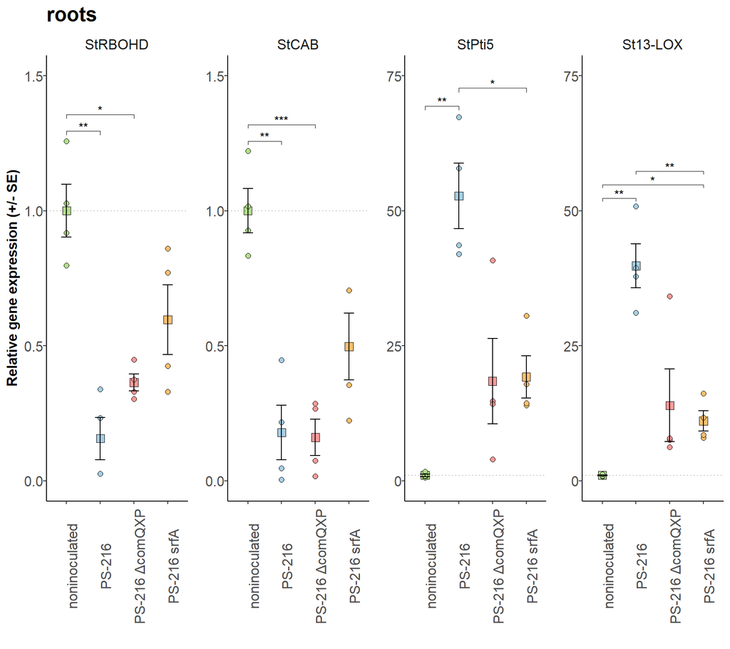

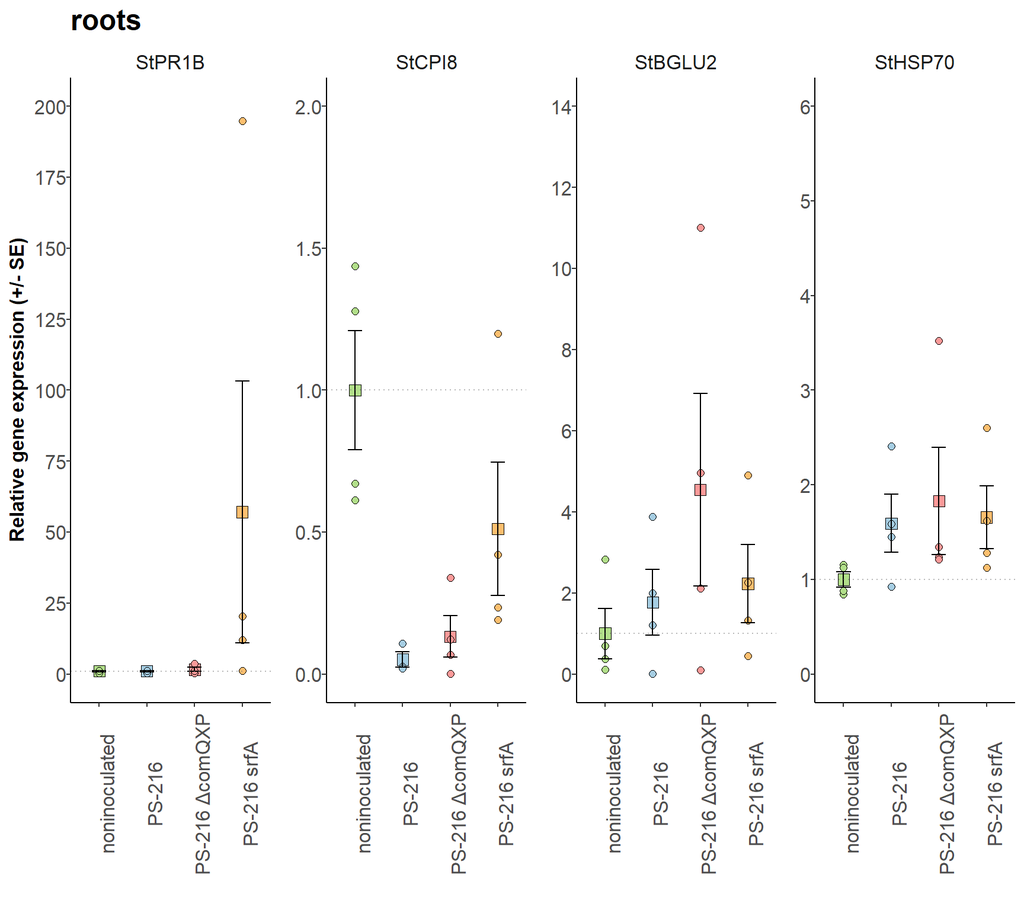

```r
max_per_transcript = roots %>%
  dplyr::group_by(transcript) %>%
  dplyr::summarise(max_scaled = max(scaled, na.rm = TRUE), .groups = "drop")
group2_names = setdiff(max_per_transcript$transcript, group1_names)
y_scales1 = build_y_scales_for(group1_names, max_per_transcript)
y_scales2 = build_y_scales_for(group2_names, max_per_transcript)

result = test_and_plot(  data_long_raw = roots
                       , myorder = myorder
                       , pal = pal
                       , what = "roots"
                       , plot_gene_expression_func = plot_gene_expression
                       , groupvars = c("Treatment", "transcript")
                       , y_scales1
                       , y_scales2
                       )
```

```r
res = result$stat.test[, grep("transcript|group1|group2|^p$|p\\.", colnames(result$stat.test))]
print(res[res$p.adj.signif != 'ns', ])
```

```
## # A tibble: 9 × 5
##   transcript group1        group2         p.adj p.adj.signif
##   <fct>      <chr>         <chr>          <dbl> <chr>
## 1 StRBOHD    noninoculated PS-216         0.003 **
## 2 StRBOHD    noninoculated PS-216 ΔcomQXP 0.016 *
## 3 StCAB      noninoculated PS-216         0.003 **
## 4 StCAB      noninoculated PS-216 ΔcomQXP 0.001 ***
## 5 StPti5     noninoculated PS-216         0.01  **
## 6 StPti5     PS-216        PS-216 srfA    0.019 *
## 7 St13-LOX   noninoculated PS-216         0.008 **
## 8 St13-LOX   noninoculated PS-216 srfA    0.038 *
## 9 St13-LOX   PS-216        PS-216 srfA    0.009 **
```

```r
cat("", file = fr, append = TRUE, sep = "\n")
output_text = "Games Howell"
cat(output_text, file = fr, append = TRUE, sep = "\n")
header = paste(colnames(res), collapse = "\t")
cat(header, file = fr, append = TRUE, sep = "\n")
output_text = apply(as.data.frame(tibble::as_tibble(res)), 1, function(row) paste(row, collapse = "\t"))
cat(output_text, file = fr, append = TRUE, sep = "\n")
cat("", file = fr, append = TRUE, sep = "\n")
cat("", file = fr, append = TRUE, sep = "\n")


ggsave(
  filename = file.path(my_dir, "roots_1.pdf"),
  plot = result$plot1,
  device = pdf,
  path = NULL,
  scale = 1,
  width = 6,
  height = 8,
  units = c("in"),
  dpi = 900,
  limitsize = TRUE,
  bg = NULL
)
ggsave(
  filename = file.path(my_dir, "roots_1.svg"),
  plot = result$plot1,
  device = svg,
  path = NULL,
  scale = 1,
  width = 6,
  height = 8,
  units = "in",
  dpi = 900,
  limitsize = TRUE,
  bg = NULL
)

ggsave(
  filename = file.path(my_dir, "roots_2.pdf"),
  plot = result$plot2,
  device = pdf,
  path = NULL,
  scale = 1,
  width = 6,
  height = 8,
  units = c("in"),
  dpi = 900,
  limitsize = TRUE,
  bg = NULL
)
ggsave(
  filename = file.path(my_dir, "roots_2.svg"),
  plot = result$plot2,
  device = svg,
  path = NULL,
  scale = 1,
  width = 6,
  height = 8,
  units = "in",
  dpi = 900,
  limitsize = TRUE,
  bg = NULL
)
```